# Benchmark Nasıl Yapılır?

Yazdığınız fonksiyonun ne kadar hızlı çalıştığını görmek veya iki farklı fonksiyon arasından daha hızlı olanı bulmak için uygulanan hız ve performans analizlerine benchmark testleri adı verilir. (Aslına bakılırsa, benchmark her türlü ölçüm ve karşılaştırma işlemlerine denir.) Bu yazıda, **R içinde benchmark testi** yapabilmemizi sağlayan birkaç yola değineceğiz.

Bu noktada performans testine neden ihtiyaç duyacağınızı düşünebilirsiniz. Sonuçta günlük çalışmalarda yazdığımız kodların büyük bir kısmı birkaç saniye içinde tamamlanıp sonuç veriyor. Gerçekten de tek bir işlemin 1 veya 5 saniyede tamamlanması pek önemli olmayabilir. **Peki ya bu işlem 1000 defa tekrarlanıyor ise? Bu durumda fonksiyondaki 4 saniyelik bir yavaşlama katlanarak 1 saatlik bir zaman kaybına yol açabilir**. Bu sebeple, uzun işlem sürelerine sahip kodları çalıştırmadan önce, küçük ölçekli veriler ile birden fazla yaklaşım deneyerek ve benchmark uygulayarak en hızlı olanın seçilmesi anlam kazanıyor.

# Basit Yol

Bir fonksiyonun ne kadar süre aldığını kullanmak için en basit yol, R’ın çekirdek fonksiyonlarından `Sys.time()` kullanmaktan geçiyor. Bu fonksiyon, çalıştığı andaki zamanın çıktısını veriyor. Süresini ölçmek istediğiniz işlemin başında ve sonunda `Sys.time()` çalıştırıp ve çıktılarını birbirinden çıkardığımızda bize harcanan süreye ulaşabiliyorsunuz. Bu şekilde geçen süreyi basitçe öğrenmek mümkün.

Bu arada, örnek olarak `Sys.sleep()` adlı fonksiyonu kullandık. Bu fonksiyon, R arayüzünü belirttiğiniz süre boyunca bekletmeye yarıyor.

```r
start <- Sys.time()
Sys.sleep(1)
stop <- Sys.time()
stop-start
```

```
## Time difference of 1.103135 secs
```

# Pratik Yol

R ile birlikte gelen bir diğer fonskiyon olan `system.time()`, bu işlemi biraz daha kolaylaştırıyor. Fonksiyon, içine yazdığınız herhangi bir komutun süresini size doğrudan iletebiliyor. Bu fonksiyon oluşturduğu 5 farklı çıktıdan 3 tanesini size doğrudan gösteriyor.

Bunlar sırasıyla, **user**, **system** ve **elapsed** değerleri. **user** (user CPU time) değeri, belirttiğiniz işlem için R tarafından harcanan CPU süresini; **system** (system CPU time) ise işletim sistemi tarafından harcanan CPU süresini gösteriyor. **elapsed** ise fonksiyonun tamamlanması için geçen gerçek süreyi belirtiyor.

```r
system.time(Sys.sleep(1))
```

```
##    user  system elapsed
##   0.000   0.001   1.004
```

# Profesyonel Yol

Bundan daha profesyonel bir benchmark yapmak istiyorsanız, `microbenchmark` gibi ek paketler yardımınıza koşuyor. Bu paket ile, bir fonksiyonun ne kadar sürede gerçekleştiğine dair tekrarlı ölçümler yapmak mümkün.

Komut içinde belirtilecek `times` parametresi ile ilgilendiğiniz fonksiyonun süresini birden fazla tekrarda ölçülmesini sağlayabiliyorsunuz. `unit` parametresi ile ölçümde kullanılacak zaman birimini değiştirebiliyorsunuz. Örneğin, “ns” nanosaniye. “us” mikrosaniye. “ms” milisaniye. “s” saniye vs. şeklinde.

```r
library("microbenchmark")
bm <- microbenchmark(Sys.sleep(1), times = 10, unit="s")
bm
```

```
## Unit: seconds
##          expr      min      lq     mean  median       uq      max neval
##  Sys.sleep(1) 1.000184 1.00119 1.003359 1.00428 1.005149 1.005169    10
```

```r
bm$time
```

```
##  [1] 1003832957 1005156957 1005148565 1004726269 1000373256 1002664426
##  [7] 1005168785 1000184173 1001189755 1005148065
```

# Uygulama

Şimdi yukarıda bahsettiğimiz `microbenchmark` uygulamasını gerçek bir örnekte deneyelim. Bu örnekte, R’ın çekirdek fonksiyonu olan ve standart sapma hesaplayan `sd()` fonksiyonu ile aynı işi sağlayacak kendi yazacağımız kod ile karşılaştıralım.

```r
# Standart sapma hesaplayan betik
sd.m    <- function(x) {sqrt(sum((x-mean(x))^2) / (length(x)-1))}

# Örnek veriseti oluşturma
sayilar <- rnorm(1000,50,5)

# Validasyon
sd.m(sayilar) == sd(sayilar)
```

```
## [1] TRUE
```

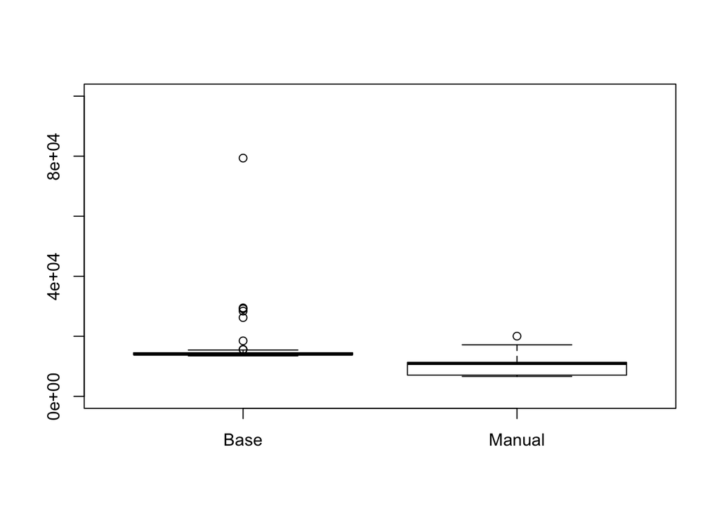

```r
# Benchmark ve Veri Düzenleme
# Çekirdek ve elle yazılan fonksiyonun sürelerini kaydedip tablo oluşturuyoruz.
base.sure   <- microbenchmark(sd(sayilar), times=100)
manual.sure <- microbenchmark(sd.m(sayilar), times=100)
tablo <- data.frame(Base=base.sure$time,
                      Manual=manual.sure$time)

# Görselleştirme
boxplot(tablo, ylim = c(0, 100000))
```

Sonuçlara baktığımızda ilginç bir şekilde çekirdek fonksiyonun daha yavaş olduğunu görebiliyoruz. Bunun sebebi, kullandığımız örnek setinin çok küçük olması. Daha büyük verisetlerinde çekirdek fonksiyonları çok daha başarı sağlayabiliyor. **Her durumda, elimizdeki veriseti için çekirdek fonksiyondan daha hızlı çalışan bir fonksiyon yazmayı başardığımız gözüküyor. (yey!)**

**Can Holyavkin**

E-posta | [Linkedin](https://www.linkedin.com/in/can-holyavkin/) | [Twitter](https://twitter.com/CanHolyavkin)